# Lab2FarrellUnstruct.

#Problem 1 List all works by Oscar Wilde (sorted by title).

```r
gutenberg_works() %>%
  filter(author == "Wilde, Oscar") %>%
  select(title) %>%
  arrange(title)
```

```
## # A tibble: 31 × 1
##    title
##    <chr>
##  1 A Critic in Pall Mall: Being Extracts from Reviews and Miscellanies
##  2 A Florentine Tragedy; La Sainte Courtisane
##  3 A House of Pomegranates
##  4 A Woman of No Importance
##  5 An Ideal Husband
##  6 Charmides, and Other Poems
##  7 Children in Prison and Other Cruelties of Prison Life
##  8 De Profundis
##  9 Essays and Lectures
## 10 For Love of the King: A Burmese Masque
## # … with 21 more rows
```

##Problem 2

```r
gutenberg_works() %>%
  filter(author == "Doyle, Arthur Conan") %>%
  arrange(title)
```

```
## # A tibble: 78 × 8
##    gutenberg_id title              author guten…¹ langu…² guten…³ rights has_t…⁴
##           <int> <chr>              <chr>    <int> <chr>   <chr>   <chr>  <lgl>
##  1        21768 "A Desert Drama: … Doyle…      69 en      <NA>    Publi… TRUE
##  2         5260 "A Duet, with an … Doyle…      69 en      <NA>    Publi… TRUE
##  3          244 "A Study in Scarl… Doyle…      69 en      Detect… Publi… TRUE
##  4         9874 "A Visit to Three… Doyle…      69 en      World … Publi… TRUE
##  5        48320 "Adventures of Sh… Doyle…      69 en      <NA>    Publi… TRUE
##  6          356 "Beyond the City"  Doyle…      69 en      <NA>    Publi… TRUE
##  7        22357 "Danger! and Othe… Doyle…      69 en      <NA>    Publi… TRUE
##  8         2350 "His Last Bow: An… Doyle…      69 en      Detect… Publi… TRUE
##  9        58574 "Index of the Pro… Doyle…      69 en      <NA>    Publi… TRUE
## 10        66991 "Memories and Adv… Doyle…      69 en      <NA>    Publi… TRUE
## # … with 68 more rows, and abbreviated variable names ¹gutenberg_author_id,
## #   ²language, ³gutenberg_bookshelf, ⁴has_text
```

##Problem 3 Sir Arthur Conan Doyle is well known for his book “The Adventures of Sherlock Holmes”. A little-known fact about him is that he was also a physician who loved poetry. Three of his published poetic works are part of the project Gutenberg archives. Find and list them (sorted by title).

```r
gutenberg_works() %>%
  filter(author == "Doyle, Arthur Conan") %>%
  select(gutenberg_id, title) %>%
  left_join(gutenberg_subjects, by = "gutenberg_id") %>%
  filter(str_detect(str_to_lower(subject), "poetry")) %>%
  select(title) %>%
  arrange(title)
```

```
## # A tibble: 3 × 1
##   title
##   <chr>
## 1 Songs Of The Road
## 2 Songs of Action
## 3 The Guards Came Through, and Other Poems
```

##Problem 4 List all works by Jane Austen which are classified as “Love stories” (sorted by title).

```r
gutenberg_works() %>%
  filter(author == "Austen, Jane") %>%
  select(gutenberg_id, title) %>%
  left_join(gutenberg_subjects, by = "gutenberg_id") %>%
  filter(str_detect(subject, "Love stories")) %>%
  select(title) %>%
  arrange(title)
```

```
## # A tibble: 7 × 1
##   title
##   <chr>
## 1 "Emma"
## 2 "Mansfield Park"
## 3 "Northanger Abbey"
## 4 "Persuasion"
## 5 "Pride and Prejudice"
## 6 "Sense and Sensibility"
## 7 "The Complete Project Gutenberg Works of Jane Austen\nA Linked Index of all P…
```

##Problem 5 Download “Sense and Sensibility” by Jane Austen from the Gutenberg library and call it sense_book. Preview the first 300 rows of the book to verify that the download came down okay.

```r
site = gutenberg_get_mirror(verbose = TRUE)
```

```
## Determining mirror for Project Gutenberg from https://www.gutenberg.org/robot/harvest
```

```
## Using mirror http://aleph.gutenberg.org
```

```r
gutenberg_works() %>%
  filter(title == "Sense and Sensibility")
```

```
## # A tibble: 1 × 8
##   gutenberg_id title               author guten…¹ langu…² guten…³ rights has_t…⁴
##          <int> <chr>               <chr>    <int> <chr>   <chr>   <chr>  <lgl>
## 1          161 Sense and Sensibil… Auste…      68 en      <NA>    Publi… TRUE
## # … with abbreviated variable names ¹gutenberg_author_id, ²language,
## #   ³gutenberg_bookshelf, ⁴has_text
```

```r
sense_book <- gutenberg_download(161, mirror = site)
slice(sense_book, 1:300)
```

```
## # A tibble: 300 × 2
##    gutenberg_id text
##           <int> <chr>
##  1          161 "[Illustration]"
##  2          161 ""
##  3          161 ""
##  4          161 ""
##  5          161 ""
##  6          161 "Sense and Sensibility"
##  7          161 ""
##  8          161 "by Jane Austen"
##  9          161 ""
## 10          161 "(1811)"
## # … with 290 more rows
```

##Problem 6 Add chapter numbers to the sense_book dataset, remove the text in Chapter 0, and preview the first 10 rows.

```r
sense_book <- sense_book %>%
  mutate(chapter = cumsum(str_detect(
    text, regex("^chapter [ivxlc]", ignore_case = TRUE)
  ))) %>%
  filter(chapter > 0) %>%
  select(chapter, text)
slice(sense_book, 1:10)
```

```
## # A tibble: 10 × 2
##    chapter text
##      <int> <chr>
##  1       1 "CHAPTER I."
##  2       1 ""
##  3       1 ""
##  4       1 "The family of Dashwood had long been settled in Sussex. Their estat…
##  5       1 "was large, and their residence was at Norland Park, in the centre o…
##  6       1 "their property, where, for many generations, they had lived in so"
##  7       1 "respectable a manner as to engage the general good opinion of their"
##  8       1 "surrounding acquaintance. The late owner of this estate was a singl…
##  9       1 "man, who lived to a very advanced age, and who for many years of hi…
## 10       1 "life, had a constant companion and housekeeper in his sister. But h…
```

##Problem 7 Tokenize the sense_book dataset and preview the first 10 rows.

```r
library(tidytext)

sense_book <- sense_book %>%
  unnest_tokens(word, text)
slice(sense_book, 1:10)
```

```
## # A tibble: 10 × 2
##    chapter word
##      <int> <chr>
##  1       1 chapter
##  2       1 i
##  3       1 the
##  4       1 family
##  5       1 of
##  6       1 dashwood
##  7       1 had
##  8       1 long
##  9       1 been
## 10       1 settled
```

##Problem 8 Using the AFINN lexicon, list the 10 most commonly used words with positive sentiment in the book.

```r
sense_book %>%
  inner_join(get_sentiments("afinn"), by = "word") %>%
  filter(value > 0) %>%
  count(word, sort = TRUE) %>%
  top_n(10, n)
```

```
## # A tibble: 10 × 2
##    word          n
##    <chr>     <int>
##  1 good        178
##  2 great       149
##  3 dear        118
##  4 happy       100
##  5 kind         95
##  6 hope         88
##  7 like         83
##  8 affection    79
##  9 better       78
## 10 love         77
```

##Problem 9 With the use of a stacked bar chart, show the ratio of negative to positive words in each chapter of the book. Use the Bing lexicon for this.

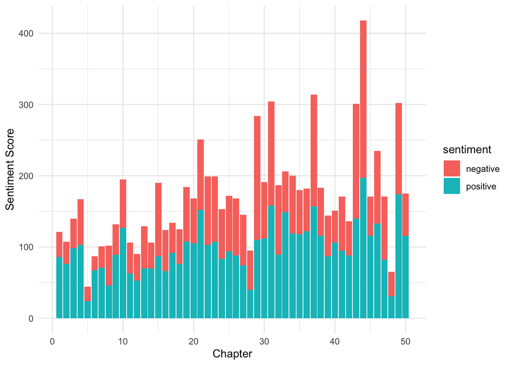

```r
sense_book %>%
  inner_join(get_sentiments("bing"), by = "word") %>%
  count(chapter, sentiment) %>%
  ggplot(mapping = aes(x = chapter, y = n, fill = sentiment)) +
  geom_col() +
  labs(x = "Chapter", y = "Sentiment Score") + theme_minimal()
```

##Problem 10 Create a series of smoothed line plots within a single chart that show trendlines of how often “trust”, “anticipation”, “joy”, “disgust”, “surprise” and “anger” sentiment words are used in each chapter of the book.

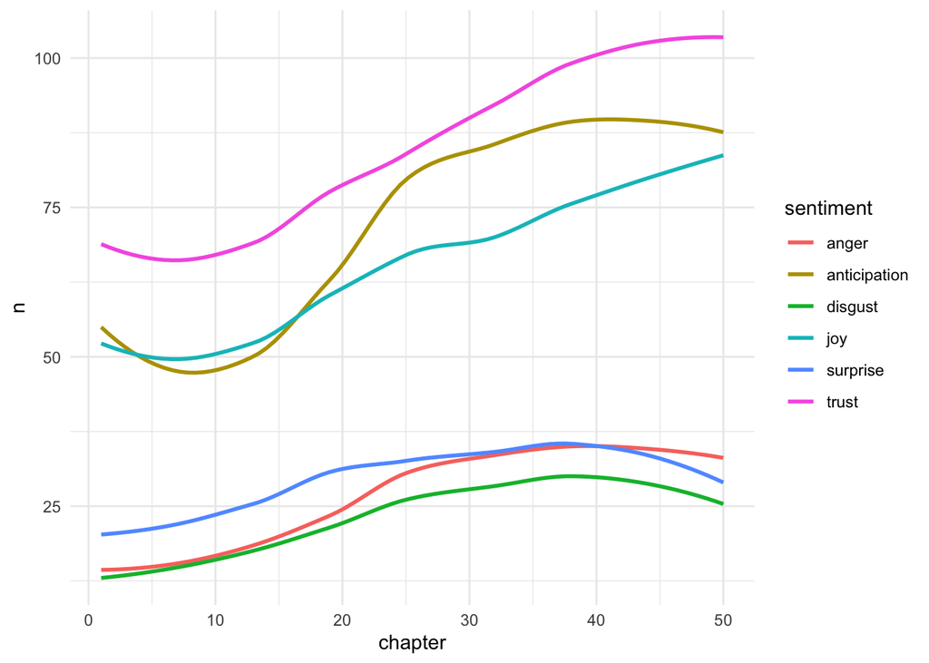

```r
sense_book %>%
  inner_join(get_sentiments("nrc"), by = "word") %>%
  filter(sentiment %in% c("anger", "anticipation", "joy", "disgust", "surprise", "trust")) %>%
  count(chapter, sentiment) %>%
  ggplot(mapping = aes(x = chapter, y = n, color = sentiment)) +
  geom_smooth(se = FALSE) +
  theme_minimal()
```